# R Notebook

Introduction (20 points)

# 5 points for specific, measurable, and clear scientific question

Is there a significant difference between the DNA binding domain of P53 genes of humans and the P53 DNA binding domains of other primates?

# 5 points for background on the protein/gene/species of interest and where the data is sourced from

P53 is a well-known tumor suppressor, often cited as the most important gene in the inhibition of cancer development. There have been many studies of now only how P53 can help prevent the onset of cancer, but as to the effects of P53 on the overall health of species, including effects on lifespan (Bartas, 2021). The DNA-binding domain (DBD) of P53 is one of the most important parts of P53, and is the most mutated area of P53 in cancers (Baugh, 2018). P53’s DBD has slight changes in many different species, which produce significant changes in their lifespans (Bartas, 2021).

Bartas paper: https://www.ncbi.nlm.nih.gov/pmc/articles/PMC8395165/ Baugh paper: https://www.nature.com/articles/cdd2017180#:~:text=The%20mutations%20located%20in%20the,in%20the%20full%20length%20protein).

# 5 points for clear, specific, and measurable scientific hypothesis that is in the form of an if-then statement

This leads me to my scientific hypothesis for this experiment: If the human P53 gene is unique in protecting the human body from developing cancer as a tumor suppressor, then because the P53 gene exists in other primates, they should all have similar characteristics to one another, whether that be through sequence or structure. Additionally, if P53 has any effects on health, then longer lifespans and can be used as an indicator for the effectiveness of different P53 DNA binding domains on overall health.

# 5 points for description of what analyses were done and how the data was downloaded for the project

I use multiple sequence alignment to compare the sequences between multiple species’ P53 gene to see the differences between them. Multiple sequence alignment would be the best technique for this because it can take multiple sequences and display all of their sequences at once and show the overall trends, as well as clearly display differences between the species.

I also plan to utilize homology modeling and structural bioinformatics to get a more comprehensive view of the overall structure of the sequences to gain a better understanding of the shape that each P53 gene takes. I hope to be able to gain insight on seeing the protein structure of each of these sequences and understanding what may cause mutations of P53.

Prior to running the MSA, we needed to create a fasta file with 9 different primate sequences. I sourced UniProt to get 9 different common primate species, and I will list them below:

1. P04637|P53_HUMAN Cellular tumor antigen p53 OS=Homo sapiens OX=9606 GN=TP53 PE=1 SV=4 https://www.uniprot.org/uniprot/P04637
2. P56423|P53_MACFA Cellular tumor antigen p53 OS=Macaca fascicularis OX=9541 GN=TP53 PE=2 SV=2 https://www.uniprot.org/uniprot/P56423
3. P61260|P53_MACFU Cellular tumor antigen p53 OS=Macaca fuscata fuscata OX=9543 GN=TP53 PE=2 SV=1 https://www.uniprot.org/uniprot/P61260
4. P13481|P53_CHLAE Cellular tumor antigen p53 OS=Chlorocebus aethiops OX=9534 GN=TP53 PE=1 SV=1 https://www.uniprot.org/uniprot/P13481
5. A0A2I2Y7Z8|A0A2I2Y7Z8_GORGO Cellular tumor antigen p53 OS=Gorilla gorilla gorilla OX=9595 PE=3 SV=1 https://www.uniprot.org/uniprot/A0A2I2Y7Z8
6. H2QC53|H2QC53_PANTR Cellular tumor antigen p53 OS=Pan troglodytes OX=9598 GN=TP53 PE=2 SV=1 https://www.uniprot.org/uniprot/H2QC53
7. H2NSL2|H2NSL2_PONAB Cellular tumor antigen p53 OS=Pongo abelii OX=9601 GN=TP53 PE=3 SV=2 https://www.uniprot.org/uniprot/H2NSL2
8. A0A8B7H7E6|A0A8B7H7E6_MICMU Cellular tumor antigen p53 OS=Microcebus murinus OX=30608 GN=TP53 PE=3 SV=1 https://www.uniprot.org/uniprot/A0A8B7H7E6
9. A0A096P2R8|A0A096P2R8_PAPAN Cellular tumor antigen p53 OS=Papio anubis OX=9555 GN=TP53 PE=3 SV=1 https://www.uniprot.org/uniprot/A0A096P2R8

I also needed to download PDB files of protein structures for 4 of my sequences:

1. Homo sapiens (Human) https://alphafold.ebi.ac.uk/entry/P04637
2. Macaca fascicularis (Crab-eating macaque) https://alphafold.ebi.ac.uk/entry/P56423
3. Macaca fuscata fuscata (Japanese macaque) https://alphafold.ebi.ac.uk/entry/P61260
4. Chlorocebus aethiops (Green monkey) https://alphafold.ebi.ac.uk/entry/P13481

Lastly, I made a copy of my original fasta file and only kept the first 4 sequences so that I could complete the RMSD analysis of the 4 strucutres.

Loading in Packages (15 points)

# 10 points for definition of each of the packages loaded

1. BioConductor Used to access many different packages to allow for data analysis
2. Biostrings Used to manipulate large biological sets of sequences
3. seqinr Used for data analysis and data visualization for biological sequences data.
4. msa An R package for multiple sequence alignment
5. muscle A package used to perform multiple sequence alignment of nucleotide or amino acid sequences, as well as other internal functions
6. Bio3D A package that allows for the analysis of protein structure, sequence, and trajectory data.
7. ggmsa A package used for visual exploration of multiple sequence alignment.
8. ape A package used for functions that allow for the reading, writing, plotting, and manipulation of phylogenetic trees.
9. NGLVieweR A package used to visualize and interact with protein databank (‘PDB’) and structural files in R
10. gplots A package used to visualize heatmaps in R

```r
# BiocManager::install("Biostrings")
# BiocManager::install("seqinr")
# BiocManager::install("msa")
# BiocManager::install("muscle")
# BiocManager::install("Bio3D")
# BiocManager::install("ggmsa")
# BiocManager::install("ape")
# install.packages("NGLVieweR")
# BiocManager::install("gplots")
```

```r
library(Biostrings)
library(seqinr)
library(msa)
library(muscle)
library(bio3d)
library(ggmsa)
library(ape)
```

```r
library(NGLVieweR)
library(gplots)
```

Performing Bioinformatics Analysis (20 points)

# 5 points for a description each of the bioinformatics method that includes data types read in and how the method works.

```r
# Multiple Sequence Alignment

# First we assign our fasta file which includes TP53 sequences from 9 different primates, and read it into the variable "Primates"
primates <- readAAStringSet("primates.fasta")

# Check to see if the sequences were read in
primates
```

```
## AAStringSet object of length 9:
##     width seq                                               names
## [1]   393 MEEPQSDPSVEPPLSQETFSDLW...SKKGQSTSRHKKLMFKTEGPDSD Homo_Sapiens
## [2]   393 MEEPQSDPSIEPPLSQETFSDLW...SKKGQSTSRHKKFMFKTEGPDSD Cynomolgus_Monkey
## [3]   393 MEEPQSDPSIEPPLSQETFSDLW...SKKGQSTSRHKKFMFKTEGPDSD Japanese_Macaque
## [4]   393 MEEPQSDPSIEPPLSQETFSDLW...SKKGQSTSRHKKFMFKTEGPDSD Green_Monkey
## [5]   403 MDDLMLSPDDIEQWFTEDPGPDE...FRLYWGIIEPPKLHTFKVCSVMI Western_Lowland_G...
## [6]   393 MEEPQSDPSVEPPLSQETFSDLW...SKKGQSTSRHKKLMFKTEGPDSD Chimpanzee
## [7]   393 MEEPQSDPSVEPPLSQETFSDLW...SKKGQSTSRHKKLMFKTEGPDSD Sumatran_Orangutan
## [8]   385 MEEPQSDLSIEAPLSQETFSDLW...SKKGQSTSRHKKLMFKREGPDSD Gray_Mouse_Lemur
## [9]   393 MEEPQSDPSIEPPLSQETFSDLW...SKKGQSTSRHKKFMFKTEGPDSD Olive_Baboon
```

```r
# Perform MSA on the alignment, assign to the variable "FirstAlignment"
primate_msa <- msa(primates)
```

```
## use default substitution matrix
```

```r
# Check to see if the MSA was executed properly
primate_msa
```

```
## CLUSTAL 2.1
##
## Call:
##    msa(primates)
##
## MsaAAMultipleAlignment with 9 rows and 442 columns
##     aln                                                    names
## [1] MEEPQSDPSVEPPLSQETFSDLWKLL...--FKT-----EGPDSD--------- Homo_Sapiens
## [2] MEEPQSDPSVEPPLSQETFSDLWKLL...--FKT-----EGPDSD--------- Chimpanzee
## [3] MEEPQSDPSIEPPLSQETFSDLWKLL...--FKT-----EGPDSD--------- Green_Monkey
## [4] MEEPQSDPSIEPPLSQETFSDLWKLL...--FKT-----EGPDSD--------- Olive_Baboon
## [5] MEEPQSDPSIEPPLSQETFSDLWKLL...--FKT-----EGPDSD--------- Cynomolgus_Monkey
## [6] MEEPQSDPSIEPPLSQETFSDLWKLL...--FKT-----EGPDSD--------- Japanese_Macaque
## [7] MEEPQSDLSIEAPLSQETFSDLWKLL...--FKR-----EGPDSD--------- Gray_Mouse_Lemur
## [8] MEEPQSDPSVEPPLSQETFSDLWKLL...--FKT-----EGPDSD--------- Sumatran_Orangutan
## [9] --------------------------...FYFRLYWGIIEPPKLHTFKVCSVMI Western_Lowland_G...
## Con MEEPQSDPSIEPPLSQETFSDLWKLL...--FKT-----EGPDSD--------- Consensus
```

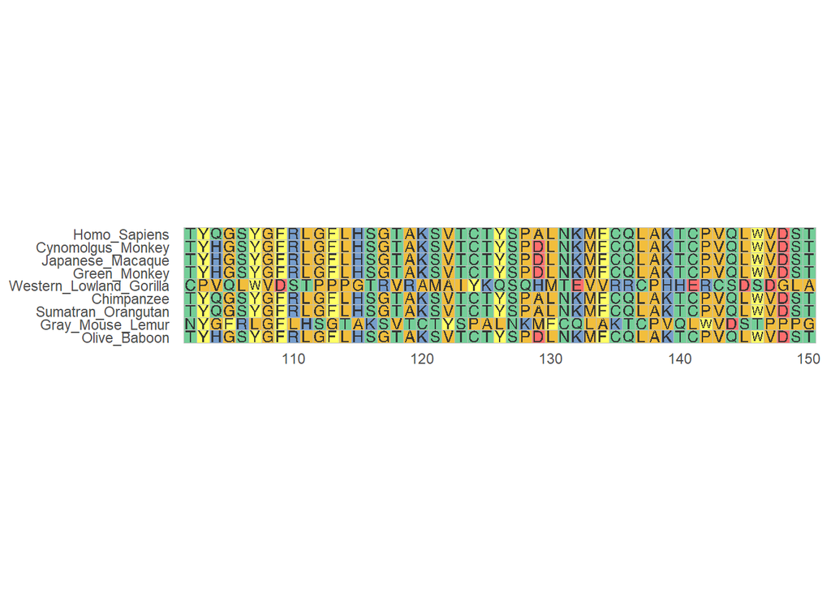

```r
# Perform MSA on the known DNA Binding Domain location (AA Sequences 102-292), broken into 4 groups for visibility purposes through the ggmsa() function.
ggmsa(primates, start = 102, end = 150, seq_name = TRUE)
```

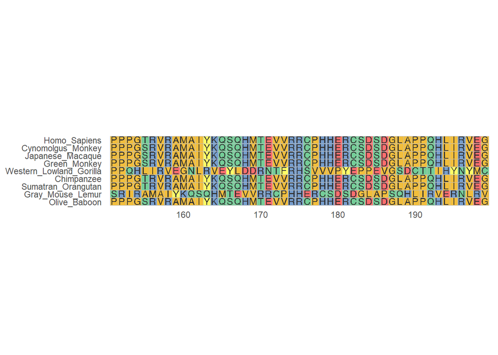

```r
ggmsa(primates, start = 151, end = 199, seq_name = TRUE)
```

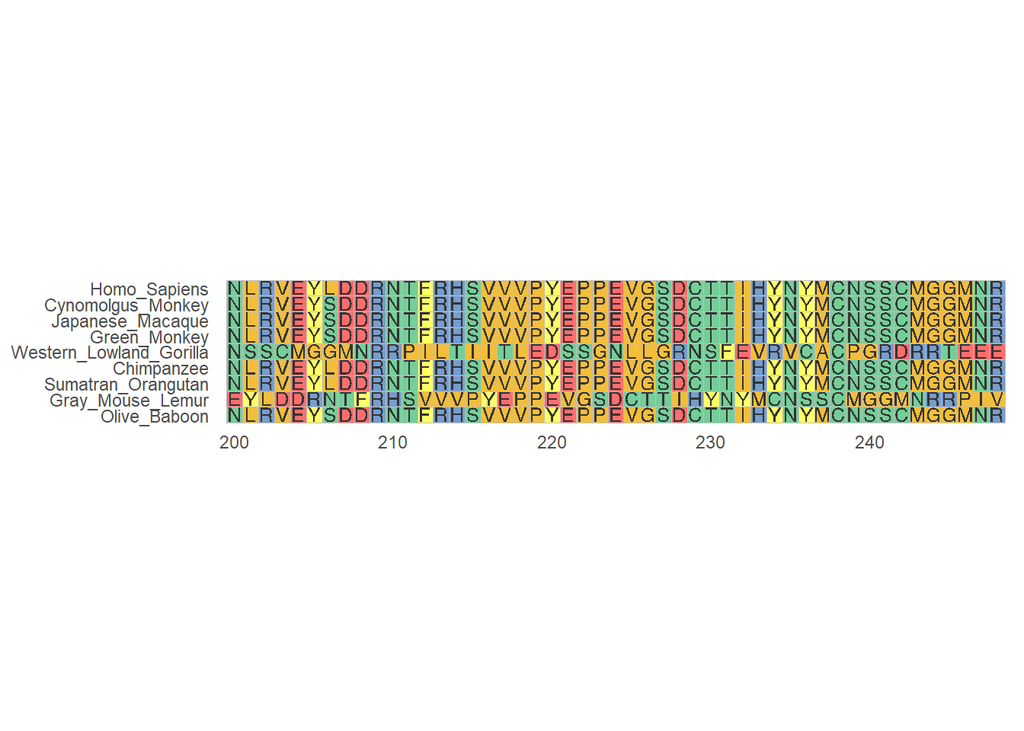

```r
ggmsa(primates, start = 200, end = 248, seq_name = TRUE)
```

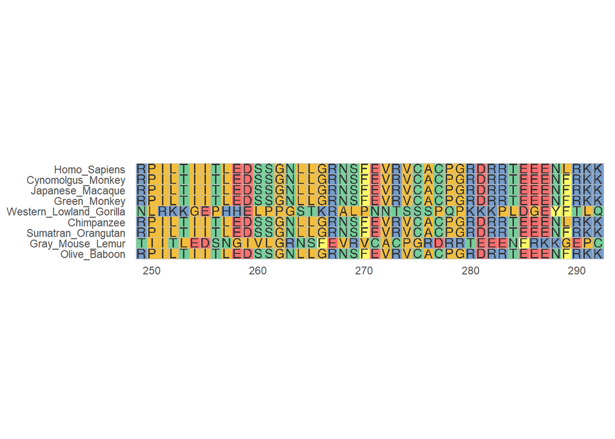

```r
ggmsa(primates, start = 249, end = 292, seq_name = TRUE)
```

```r
# We will create an R function that we can use to return the sequence identity between a human and a certain primate

# We will assign the function get_pid() the arguments of seq1 and seq2
get_pid <- function(seq1, seq2){

  # The variable aligned_pair is the pairwise alignment between seq1 and seq2
  aligned_pair <- pairwiseAlignment(seq1, seq2, substitutionMatrix = "BLOSUM50",
                                    gapOpening = -2, gapExtension = -8,
                                    scoreOnly = FALSE)

  # The variable pid_val is the percent identity of the pairwise alignments from aligned_pair.
  pid_val <- pid(aligned_pair, type="PID1")

}

# Next, we will find the pid between human and other primates.

# We create 2 vectors "name_vector" and "pid_vector."
name_vector <- c()
pid_vector <- c()

# We make a for loop that finds the pid between humans and other primates
for (i in 2:length(primates)){

  # This section gets the primates' name and sequence.
  primate_seq <- primates[i]
  primate_name <- names(primate_seq)

  # This stores the name into the name_vector
  name_vector <- c(name_vector, primate_name)

  # This section gets the percent identity
  human_primate_pid <- get_pid(primates[1], primate_seq)

  # This stores the percent identity into the pid_vector
  pid_vector <- c(pid_vector, human_primate_pid)

}

# Lastly, we create a dataframe to cleanly present our percent identities.
pid_df <- data.frame(Primate = name_vector, percent_identity = pid_vector)
pid_df
```

| Primate | percent_identity |
| --- | --- |
| Cynomolgus_Monkey | 95.67430 |
| Japanese_Macaque | 95.67430 |
| Green_Monkey | 95.67430 |
| Western_Lowland_Gorilla | 76.13636 |
| Chimpanzee | 100.00000 |
| Sumatran_Orangutan | 97.70992 |
| Gray_Mouse_Lemur | 86.00509 |
| Olive_Baboon | 95.67430 |

```r
# Phylogenetic Trees

# I sourced code from https://bioconductor.org/packages/devel/bioc/vignettes/msa/inst/doc/msa.pdf to produce this phylogenetic clustering.

# First we convert the MSA of Primates to be utilized by the seqinr package through the msaConvert() function.
primate_msa_converted <- msaConvert(primate_msa, type="seqinr::alignment")

# Then we create a distance matrix with the dist.alignment() function from the seqinr package
primate_msa_distance <- dist.alignment(primate_msa_converted, "identity")
as.matrix(primate_msa_distance)[1:9, drop=FALSE]
```

```
## [1] 0.0000000 0.0000000 0.2079832 0.2079832 0.2079832 0.2079832 0.3493965
## [8] 0.1513300 0.2548956
```

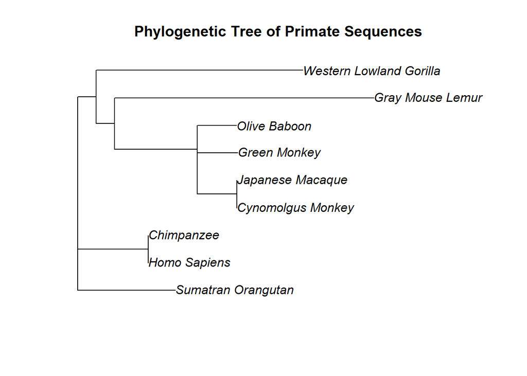

```r
# We can create the phylogenetic tree of the Primates through the nj() function of the ape package
primate_tree <- nj(primate_msa_distance)

# Now we plot our results.
plot(primate_tree, main = "Phylogenetic Tree of Primate Sequences")
```

```r
# Homology Modeling and Structural Bioinformatics

# I found my 4 protein structures for the human, crab eating macaque, japanese macaque, and monkey through RCSB PDB, and selecting the AlphaFold form of the structure when going to the 'structure' tab of the P53 genes.

# To generate protein strucutres, we first need to set our PDB database pdb files as a vector
proteins <- c("human.pdb", "crab_eating_macaque.pdb", "japanese_macaque.pdb", "monkey.pdb")

# Next, we will want to create a function, which we will call display() for displaying the 3D protein structures
display <- function (x){

# We can use the example "# Example 1: Most Basic" when accessing '?NGLVieweR' to create the proper function for making the interactive 3D structures
  print(NGLVieweR(x) %>%
  addRepresentation("cartoon",
    param = list(name = "cartoon", colorScheme = "residueindex")
  ))
}

# We can display all 4 of our proteins using a for loop using our "display" function
for (i in 1:4){
  display(proteins[i])
}
# Root Mean Square Deviation

# I referenced code from http://thegrantlab.org/bio3d_v2/html/rmsd.html and adapted it for my primate sequences.

# First we will read in the pdb file using the read.pdb() function.
human_pdb <- read.pdb("human.pdb")
human_pdb
```

[output not shown]

```
##
##  Call:  read.pdb(file = "human.pdb")
##
##    Total Models#: 1
##      Total Atoms#: 3060,  XYZs#: 9180  Chains#: 1  (values: A)
##
##      Protein Atoms#: 3060  (residues/Calpha atoms#: 393)
##      Nucleic acid Atoms#: 0  (residues/phosphate atoms#: 0)
##
##      Non-protein/nucleic Atoms#: 0  (residues: 0)
##      Non-protein/nucleic resid values: [ none ]
##
##    Protein sequence:
##       MEEPQSDPSVEPPLSQETFSDLWKLLPENNVLSPLPSQAMDDLMLSPDDIEQWFTEDPGP
##       DEAPRMPEAAPPVAPAPAAPTPAAPAPAPSWPLSSSVPSQKTYQGSYGFRLGFLHSGTAK
##       SVTCTYSPALNKMFCQLAKTCPVQLWVDSTPPPGTRVRAMAIYKQSQHMTEVVRRCPHHE
##       RCSDSDGLAPPQHLIRVEGNLRVEYLDDRNTFRHSVVVPYEPPEV...<cut>...PDSD
##
## + attr: atom, xyz, seqres, calpha, call
```

```r
# We created a new fasta file, named "4_primates.fasta," which contain only the 4 primate sequences that we are using in the structural bioinformatics portion of our assignment, and assigned it to the value of aln.
aln <- read.fasta("4_primates.fasta")

# We use the read.fasta.pdb() function to read the 4 fasta files in aln into pdbs, which we assign to the value pdbs.
pdbs <- read.fasta.pdb(aln, pdbext = ".pdb")
```

```
## pdb/seq: 1   name: human
## pdb/seq: 2   name: crab_eating_macaque
## pdb/seq: 3   name: japanese_macaque
## pdb/seq: 4   name: monkey
```

```r
# Check the pdbs to see that they are all there.
pdbs
```

```
##                       1        .         .         .         .         50
## human                 MEEPQSDPSVEPPLSQETFSDLWKLLPENNVLSPLPSQAMDDLMLSPDDI
## crab_eating_macaque   MEEPQSDPSIEPPLSQETFSDLWKLLPENNVLSPLPSQAVDDLMLSPDDL
## japanese_macaque      MEEPQSDPSIEPPLSQETFSDLWKLLPENNVLSPLPSQAVDDLMLSPDDL
## monkey                MEEPQSDPSIEPPLSQETFSDLWKLLPENNVLSPLPSQAVDDLMLSPDDL
##                       *********^*****************************^*********^
##                       1        .         .         .         .         50
##
##                      51        .         .         .         .         100
## human                 EQWFTEDPGPDEAPRMPEAAPPVAPAPAAPTPAAPAPAPSWPLSSSVPSQ
## crab_eating_macaque   AQWLTEDPGPDEAPRMSEAAPPMAPTPAAPTPAAPAPAPSWPLSSSVPSQ
## japanese_macaque      AQWLTEDPGPDEAPRMSEAAPPMAPTPAAPTPAAPAPAPSWPLSSSVPSQ
## monkey                AQWLTEDPGPDEAPRMSEAAPHMAPTPAAPTPAAPAPAPSWPLSSSVPSQ
##                        ** ************ **** ^** ************************
##                      51        .         .         .         .         100
##
##                     101        .         .         .         .         150
## human                 KTYQGSYGFRLGFLHSGTAKSVTCTYSPALNKMFCQLAKTCPVQLWVDST
## crab_eating_macaque   KTYHGSYGFRLGFLHSGTAKSVTCTYSPDLNKMFCQLAKTCPVQLWVDST
## japanese_macaque      KTYHGSYGFRLGFLHSGTAKSVTCTYSPDLNKMFCQLAKTCPVQLWVDST
## monkey                KTYHGSYGFRLGFLHSGTAKSVTCTYSPDLNKMFCQLAKTCPVQLWVDST
##                       *** ************************ *********************
##                     101        .         .         .         .         150
##
##                     151        .         .         .         .         200
## human                 PPPGTRVRAMAIYKQSQHMTEVVRRCPHHERCSDSDGLAPPQHLIRVEGN
## crab_eating_macaque   PPPGSRVRAMAIYKQSQHMTEVVRRCPHHERCSDSDGLAPPQHLIRVEGN
## japanese_macaque      PPPGSRVRAMAIYKQSQHMTEVVRRCPHHERCSDSDGLAPPQHLIRVEGN
## monkey                PPPGSRVRAMAIYKQSQHMTEVVRRCPHHERCSDSDGLAPPQHLIRVEGN
##                       ****^*********************************************
##                     151        .         .         .         .         200
##
##                     201        .         .         .         .         250
## human                 LRVEYLDDRNTFRHSVVVPYEPPEVGSDCTTIHYNYMCNSSCMGGMNRRP
## crab_eating_macaque   LRVEYSDDRNTFRHSVVVPYEPPEVGSDCTTIHYNYMCNSSCMGGMNRRP
## japanese_macaque      LRVEYSDDRNTFRHSVVVPYEPPEVGSDCTTIHYNYMCNSSCMGGMNRRP
## monkey                LRVEYSDDRNTFRHSVVVPYEPPEVGSDCTTIHYNYMCNSSCMGGMNRRP
##                       ***** ********************************************
##                     201        .         .         .         .         250
##
```

[output cut: 18 more lines]

```
## japanese_macaque      KDAQAGKEPAGSRAHSSHLKSKKGQSTSRHKKFMFKTEGPDSD
## monkey                KDAQAGKEPAGSRAHSSHLKSKKGQSTSRHKKFMFKTEGPDSD
##                       *********^********************** **********
##                     351        .         .         .         .  393
##
## Call:
##   read.fasta.pdb(aln = aln, pdbext = ".pdb")
##
## Class:
##   pdbs, fasta
##
## Alignment dimensions:
##   4 sequence rows; 393 position columns (393 non-gap, 0 gap)
##
## + attr: xyz, resno, b, chain, id, ali, resid, sse, call
```

```r
# Gap positions
inds <- gap.inspect(pdbs$xyz)

# Now we can begin the RMSD analysis

# First we take the RMSD between structure 1 and the other structures in the alignment, and assign it to the value of rmsd_human
rmsd_human <- rmsd(a=pdbs$xyz[1,], b=pdbs, a.inds=inds$f.inds, b.inds=inds$f.inds, fit=TRUE)

# Run the RMSD of rmsd_human
rmsd_human
```

```
##               human crab_eating_macaque    japanese_macaque              monkey
##               0.000               6.551              10.140               9.788
```

```r
# Next, we can take the RMSD between all structures against all structures in the alignment, and assign it to the value of rmsd_all.
rmsd_all <- rmsd(pdbs$xyz)
# Run the RMSD of rmsd_all.
rmsd_all
```

```
##                      human crab_eating_macaque japanese_macaque monkey
## human                0.000              29.571           15.075 13.291
## crab_eating_macaque 29.571               0.000           34.436 25.966
## japanese_macaque    15.075              34.436            0.000 10.457
## monkey              13.291              25.966           10.457  0.000
```

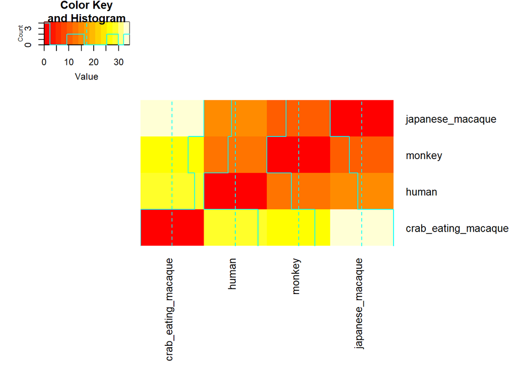

```r
# For a more clear visualization of these numbers, we will create a heatmap to see the differences between the primate species, and assign it to the value of primate_heatmap.
primate_heatmap <- heatmap.2(rmsd_all, dendrogram = "none", margins=c(10,10), cexRow = 1, cexCol = 1)
```

```r
# Run the heatmap of primate_heatmap.
primate_heatmap
```

[output not shown]

[output cut: 10 more lines]

[output not shown]

# 5 points for code working correctly

# 5 points for adequate commenting in the code and code checks

# 5 points for a function written that performs some part of the bioinformatics analyses

Plotting The Results (15 points)

# 5 points for description of data analysis method

# 5 points for the code working for data analysis method

# 5 points for adequate commenting in the code for the data analysis method

Analyzing the Results (15 points)

# 15 points for correctly analyzing the data

From what can be observed, we can determine that most of the sequences are very similar to each other, while the gorilla sequence A0A2I2Y7Z8|A0A2I2Y7Z8_GORGO appears to be the most unique, and it has the least similarity to the rest of the primates. The sequence for the lemur, A0A8B7H7E6|A0A8B7H7E6_MICMU, is also more unique compared to the rest of the sequences. This was determined through the use of multiple sequence alignment, and is supported through the phylogenetic tree that is formed in the data analysis section. The gorilla and lemur are clearly the furthest away phylogenetically from the homo sapien species. This is further supported through the calculation performed of percent identity, which shows that the gorilla P53 gene is least related to humans, and the lemur P53 gene is also not very closely related.

Code Formatting Requirements (15 points)

# 5 points for comments identifying global variables and local variables with in depth explanations of each

# 5 points for use of a built-in Bioconductor or Biopython function (or some other tool that was discussed in class like NumPy or SciPy), and description of what the function reads in and what it returns.

# 5 points for hard-coding/redundant code being absent.